# DFOIL replication

I’m trying to replicate and poke around Figure 3 of Pease and Hahn (Pease and Hahn 2015).

## Coalescent simulation

Pease and Hahn use *ms* (Hudson 2002) to simulate samples of genetic regions evolving under Wright-Fisher model, whereas I wrote my own coalescent simulator. My approach is simpler but it’s a bit of a compromise when it comes to introducing a mutation in the gene tree obtained. In reality (and in *ms* but not in my coalescent simulations) gene trees have a higher chance to include mutations when they coalesce deeper, and reverse and convergent mutations do happen. I’m considering replacing function introducing mutations with a fancier one that uses Poisson distribution, allowing recurrent and convergent mutations. Also considering seeking, downloading and using the simulated data used by Pease and Hahn.

Let’s load the coalescent simulation and visualization functions I wrote:

```r
solve_branch <- function(branch, coalescent_times, start, end) {
    # If there's at most one lineage in the branch during the time period, nothing needs to be done.
    if (length(branch$inhabitants) > 1) {
    # If there's at least one coalescent event during the time frame, we record it and call the function recursively.
      minimum_time <- rexp(1, rate = choose(length(branch$inhabitants), 2)*branch$lambda)
      if (minimum_time < end - start) {
        pair <- sample(branch$inhabitants, 2)
        new <- paste(pair[1], pair[2], sep = "")
        branch$inhabitants <- setdiff(c(branch$inhabitants, new), pair)
        coalescent_times[[new]] <- minimum_time + start
        inner <- solve_branch(branch, coalescent_times, minimum_time + start, end)
        branch <- inner$branch
        coalescent_times <- inner$coalescent_times
      }
    }
    return(list(branch = branch, coalescent_times = coalescent_times))
}

solve_tree <- function(branches) {
    coalescent_times <- list()
    # Compile a vector of pivotal moments (individual sampling times, population divergence and admixture times).
    pivotal <- numeric(0)
    for (branch in branches) {
    for (sample in branch$samples) {pivotal <- c(pivotal, sample)}
        for (switch in branch$switches) {pivotal <- c(pivotal, switch[1])}
    }
    pivotal <- unique(pivotal)
    pivotal <- pivotal[order(pivotal)]
    # Add infinity as the last pivotal moment.
    pivotal[length(pivotal) + 1] <- Inf
    # For all pivotal moments except the infinity:
    for (t in seq(1, length(pivotal) - 1)) {
        now <- pivotal[t]
      soon <- pivotal[t + 1]
      # First perform the special actions of the pivotal moment (samplings, switches).
      for (branch in names(branches)) {
      for (sample in names(branches[[branch]]$samples)) {
        if (branches[[branch]]$samples[[sample]] == now) {
            branches[[branch]]$inhabitants <- c(branches[[branch]]$inhabitants, sample)
            coalescent_times[[sample]] <- now
        }
      }
        for (switch in names(branches[[branch]]$switches)) {
            if (branches[[branch]]$switches[[switch]][1] == now) {
              # Moving inhabitants from a branch to another, possibly.
                for (inhabitant in branches[[branch]]$inhabitants) {
                  if (runif(1) < branches[[branch]]$switches[[switch]][2]) {
                    branches[[branch]]$inhabitants <- setdiff(branches[[branch]]$inhabitants, inhabitant)
                    branches[[switch]]$inhabitants <- c(branches[[switch]]$inhabitants, inhabitant)
                  }
                }
            }
        }
      }
      # Then solve each branch until the next pivotal moment.
      for (branch in names(branches)) {
        solved <- solve_branch(branches[[branch]], coalescent_times, now, soon)
        branches[[branch]] <- solved$branch
        coalescent_times <- solved$coalescent_times
      }
    }
    return(coalescent_times)
}

subsetstring <- function(x, y) {
    return(all(unlist(strsplit(x, "")) %in% unlist(strsplit(y, ""))))
}

plot_gene_trees <- function(gene_trees, species_tree) {
    mypalette <- colorRampPalette(c("purple", "pink"))(length(gene_trees))
    if (missing(species_tree) == FALSE) { # Last plot the species tree on black
        gene_trees[[length(gene_trees) + 1]] <- species_tree
        mypalette[length(mypalette) + 1] <- "black"
    }
    x <- numeric(0)
    y <- numeric(0)
    xend <- numeric(0)
    yend <- numeric(0)
    colors <- character(0)
    for (t in seq(1, length(gene_trees))) {
        tree <- gene_trees[[t]]
        color <- mypalette[t]
        for (node in names(tree)) {
            candidates <- names(tree)[nchar(names(tree)) > nchar(node)]
            if (length(candidates > 0)) {
          candidates <- candidates[sapply(candidates, subsetstring, x = node)]
              if (length(candidates) > 0) {
                parent <- candidates[which.min(nchar(candidates))]
                  x[length(x) + 1] <- mean(as.numeric(unlist(strsplit(node, "P"))), na.rm = TRUE)
                  y[length(y) + 1] <- tree[[node]]
                  xend[length(xend) + 1] <- mean(as.numeric(unlist(strsplit(parent, "P"))), na.rm = TRUE)
                  yend[length(yend) + 1] <- tree[[parent]]
                  colors[length(colors) + 1] <- color
              }
            }
        }
    }
    df <- data.frame(x = x, y = y, xend = xend, yend = yend, colors = colors)
    ggplot(df) +
        theme_void() +
    geom_segment(aes(x = x, y = y, xend = xend, yend = yend), color = colors)
}

pattern <- function(tree) {
  # Adding one point mutation somewhere in the gene tree and reporting the ABBABABA-pattern.
    # Ignoring the fact that some trees have higher chance of point mutation than others.
    # Ignoring recurrent and convergent mutations as well.
    # Pease and Hahn cite Durand (2011) saying it's no big deal.
    L <- rep(0, length(names(tree)))
    for (n in seq(1, length(names(tree)))) {
      node <- names(tree)[n]
        candidates <- names(tree)[nchar(names(tree)) > nchar(node)]
        if (length(candidates > 0)) {
      candidates <- candidates[sapply(candidates, subsetstring, x = node)]
            if (length(candidates) > 0) {
              parent <- candidates[which.min(nchar(candidates))]
                L[n] <- tree[[parent]] - tree[[node]]
            }
      }
    }
    random <- runif(1)*sum(L)
    lsum <- 0
    for (l in seq(1, length(L))) {
        lsum <- lsum + L[l]
        if (lsum > random) {break()}
    } # names(tree)[l] is the first node affected by the mutation.
    leaves <- max(nchar(names(tree)))/2
    pattern <- rep("A", leaves)
    for (j in seq(1, leaves)) {
        if (grepl(paste(j), names(tree)[l])) {pattern[j] <- "B"}
    }
    return(paste(pattern, collapse = ""))
}
```

Visualizing some gene trees, species tree drawn black.

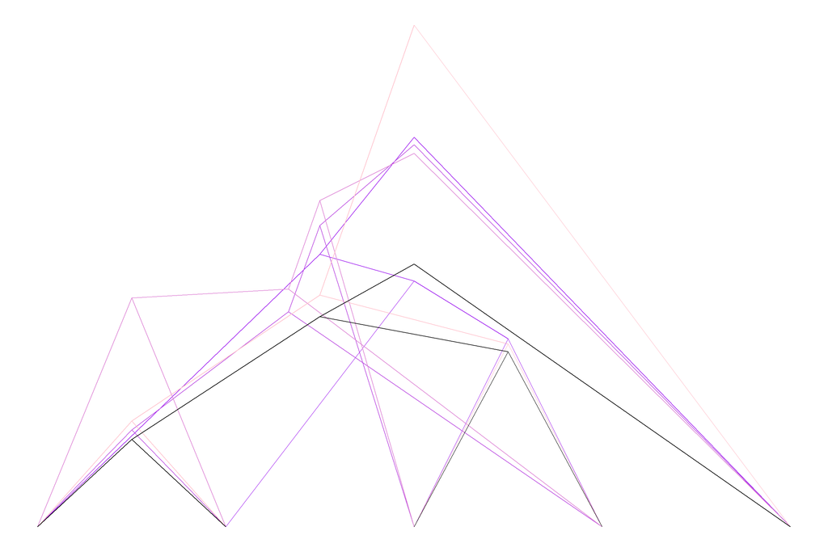

```r
LL <- list(lambda = 2, inhabitants = character(0), samples = list(P1 = 0), switches = list(LR = c(0.5, 1)))
LR <- list(lambda = 2, inhabitants = character(0), samples = list(P2 = 0), switches = list(RR = c(1.2, 1)))
RL <- list(lambda = 2, inhabitants = character(0), samples = list(P3 = 0), switches = list(RR = c(1, 1)))
RR <- list(lambda = 2, inhabitants = character(0), samples = list(P4 = 0), switches = list(OG = c(1.5, 1)))
OG <- list(lambda = 2, inhabitants = character(0), samples = list(P5 = 0), switches = list())
tree <- list(LL = LL, LR = LR, RL = RL, RR = RR, OG = OG)
LL <- list(lambda = Inf, inhabitants = character(0), samples = list(P1 = 0), switches = list(LR = c(0.5, 1)))
LR <- list(lambda = Inf, inhabitants = character(0), samples = list(P2 = 0), switches = list(RR = c(1.2, 1)))
RL <- list(lambda = Inf, inhabitants = character(0), samples = list(P3 = 0), switches = list(RR = c(1, 1)))
RR <- list(lambda = Inf, inhabitants = character(0), samples = list(P4 = 0), switches = list(OG = c(1.5, 1)))
OG <- list(lambda = Inf, inhabitants = character(0), samples = list(P5 = 0), switches = list())
species_tree <- solve_tree(list(LL = LL, LR = LR, RL = RL, RR = RR, OG = OG))
gene_trees <- list()
for (j in seq(1, 4)) {gene_trees[[j]] <- solve_tree(tree)}
plot_gene_trees(gene_trees, species_tree)
```

## Patterson’s D-statistic and its derivatives

The function `DPA()` is the Patterson’s D-statistic, `DFO()`, `DIL()`, `DFI()` and `DOL()` are the statistics defined by Pease and Hahn. The functions `dfo()`, `dil()`, `dfi()` and `dol()` are versions with the private allele contribution removed (these won’t work as we’ll see later). Then there’s the older statistics discussed in the Pease and Hahn paper, will implement them also. All the functions by default treat both patterns “ABBA” and “BAAB” the same, if you only want to accept patterns ending with “A”, set `strict = TRUE`.

```r
n <- function(X, x) {
    if (x %in% names(X)) {return(X[x])} else {return(0)}
}

DPA <- function(X, strict = FALSE) {
    L <- n(X, "BABA")
    R <- n(X, "ABBA")
    if (strict == FALSE) {
        L <- L + n(X, "ABAB")
        R <- R + n(X, "BAAB")
    }
    value <- as.numeric((L - R)/(L + R))
    pvalue <- as.numeric(1 - pchisq(abs((L - R)**2/(L + R)), 1))
    if (is.numeric(pvalue) == TRUE && is.nan(pvalue) == FALSE) {
        if (pvalue > 0.01) {
            sign <- "0"
        } else {
            if (value > 0) {sign <- "+"}
        if (value < 0) {sign <- "-"}
        }
    } else {sign <- "?"}
  return(list(value, pvalue, sign))
}

DFO <- function(X, strict = FALSE) {
    L <- n(X, "BABAA") + n(X, "BBBAA") + n(X, "ABABA") + n(X, "AAABA")
    R <- n(X, "BAABA") + n(X, "BBABA") + n(X, "ABBAA") + n(X, "AABAA")
    if (strict == FALSE) {
        L <- L + n(X, "ABABB") + n(X, "AAABB") + n(X, "BABAB") + n(X, "BBBAB")
        R <- R + n(X, "ABBAB") + n(X, "AABAB") + n(X, "BAABB") + n(X, "BBABB")
    }
    value <- as.numeric((L - R)/(L + R))
    pvalue <- as.numeric(1 - pchisq(abs((L - R)**2/(L + R)), 1))
    if (is.numeric(pvalue) == TRUE && is.nan(pvalue) == FALSE) {
        if (pvalue > 0.01) {
            sign <- "0"
        } else {
            if (value > 0) {sign <- "+"}
        if (value < 0) {sign <- "-"}
        }
    } else {sign <- "?"}
  return(list(value, pvalue, sign))
}

DIL <- function(X, strict = FALSE) {
    L <- n(X, "ABBAA") + n(X, "BBBAA") + n(X, "BAABA") + n(X, "AAABA")
    R <- n(X, "ABABA") + n(X, "BBABA") + n(X, "BABAA") + n(X, "AABAA")
    if (strict == FALSE) {
        L <- L + n(X, "BAABB") + n(X, "AAABB") + n(X, "ABBAB") + n(X, "BBBAB")
        R <- R + n(X, "BABAB") + n(X, "AABAB") + n(X, "ABABB") + n(X, "BBABB")
    }
    value <- as.numeric((L - R)/(L + R))
    pvalue <- as.numeric(1 - pchisq(abs((L - R)**2/(L + R)), 1))
    if (is.numeric(pvalue) == TRUE && is.nan(pvalue) == FALSE) {
        if (pvalue > 0.01) {
            sign <- "0"
        } else {
            if (value > 0) {sign <- "+"}
        if (value < 0) {sign <- "-"}
        }
    } else {sign <- "?"}
  return(list(value, pvalue, sign))
}

DFI <- function(X, strict = FALSE) {
    L <- n(X, "BABAA") + n(X, "BABBA") + n(X, "ABABA") + n(X, "ABAAA")
    R <- n(X, "ABBAA") + n(X, "ABBBA") + n(X, "BAABA") + n(X, "BAAAA")
    if (strict == FALSE) {
        L <- L + n(X, "ABABB") + n(X, "ABAAB") + n(X, "BABAB") + n(X, "BABBB")
        R <- R + n(X, "BAABB") + n(X, "BAAAB") + n(X, "ABBAB") + n(X, "ABBBB")
    }
    value <- as.numeric((L - R)/(L + R))
    pvalue <- as.numeric(1 - pchisq(abs((L - R)**2/(L + R)), 1))
    if (is.numeric(pvalue) == TRUE && is.nan(pvalue) == FALSE) {
        if (pvalue > 0.01) {
            sign <- "0"
        } else {
            if (value > 0) {sign <- "+"}
        if (value < 0) {sign <- "-"}
        }
    } else {sign <- "?"}
  return(list(value, pvalue, sign))
}

DOL <- function(X, strict = FALSE) {
    L <- n(X, "BAABA") + n(X, "BABBA") + n(X, "ABBAA") + n(X, "ABAAA")
    R <- n(X, "ABABA") + n(X, "ABBBA") + n(X, "BABAA") + n(X, "BAAAA")
    if (strict == FALSE) {
        L <- L + n(X, "ABBAB") + n(X, "ABAAB") + n(X, "BAABB") + n(X, "BABBB")
        R <- R + n(X, "BABAB") + n(X, "BAAAB") + n(X, "ABABB") + n(X, "ABBBB")
    }
    value <- as.numeric((L - R)/(L + R))
    pvalue <- as.numeric(1 - pchisq(abs((L - R)**2/(L + R)), 1))
    if (is.numeric(pvalue) == TRUE && is.nan(pvalue) == FALSE) {
        if (pvalue > 0.01) {
            sign <- "0"
        } else {
            if (value > 0) {sign <- "+"}
        if (value < 0) {sign <- "-"}
        }
    } else {sign <- "?"}
  return(list(value, pvalue, sign))
}

dfo <- function(X, strict = FALSE) {
    L <- n(X, "BABAA") + n(X, "BBBAA") + n(X, "ABABA")
    R <- n(X, "BAABA") + n(X, "BBABA") + n(X, "ABBAA")
    if (strict == FALSE) {
        L <- L + n(X, "ABABB") + n(X, "AAABB") + n(X, "BABAB")
        R <- R + n(X, "ABBAB") + n(X, "AABAB") + n(X, "BAABB")
    }
    value <- as.numeric((L - R)/(L + R))
    pvalue <- as.numeric(1 - pchisq(abs((L - R)**2/(L + R)), 1))
    if (is.numeric(pvalue) == TRUE && is.nan(pvalue) == FALSE) {
        if (pvalue > 0.01) {
            sign <- "0"
        } else {
            if (value > 0) {sign <- "+"}
        if (value < 0) {sign <- "-"}
        }
    } else {sign <- "?"}
  return(list(value, pvalue, sign))
}

dil <- function(X, strict = FALSE) {
    L <- n(X, "ABBAA") + n(X, "BBBAA") + n(X, "BAABA")
    R <- n(X, "ABABA") + n(X, "BBABA") + n(X, "BABAA")
    if (strict == FALSE) {
        L <- L + n(X, "BAABB") + n(X, "AAABB") + n(X, "ABBAB")
        R <- R + n(X, "BABAB") + n(X, "AABAB") + n(X, "ABABB")
    }
    value <- as.numeric((L - R)/(L + R))
    pvalue <- as.numeric(1 - pchisq(abs((L - R)**2/(L + R)), 1))
    if (is.numeric(pvalue) == TRUE && is.nan(pvalue) == FALSE) {
        if (pvalue > 0.01) {
            sign <- "0"
        } else {
            if (value > 0) {sign <- "+"}
        if (value < 0) {sign <- "-"}
        }
    } else {sign <- "?"}
  return(list(value, pvalue, sign))
}

dfi <- function(X, strict = FALSE) {
    L <- n(X, "BABAA") + n(X, "BABBA") + n(X, "ABABA")
    R <- n(X, "ABBAA") + n(X, "ABBBA") + n(X, "BAABA")
    if (strict == FALSE) {
        L <- L + n(X, "ABABB") + n(X, "ABAAB") + n(X, "BABAB")
        R <- R + n(X, "BAABB") + n(X, "BAAAB") + n(X, "ABBAB")
    }
    value <- as.numeric((L - R)/(L + R))
    pvalue <- as.numeric(1 - pchisq(abs((L - R)**2/(L + R)), 1))
    if (is.numeric(pvalue) == TRUE && is.nan(pvalue) == FALSE) {
        if (pvalue > 0.01) {
            sign <- "0"
        } else {
            if (value > 0) {sign <- "+"}
        if (value < 0) {sign <- "-"}
        }
    } else {sign <- "?"}
  return(list(value, pvalue, sign))
}

dol <- function(X, strict = FALSE) {
    L <- n(X, "BAABA") + n(X, "BABBA") + n(X, "ABBAA")
    R <- n(X, "ABABA") + n(X, "ABBBA") + n(X, "BABAA")
    if (strict == FALSE) {
        L <- L + n(X, "ABBAB") + n(X, "ABAAB") + n(X, "BAABB")
        R <- R + n(X, "BABAB") + n(X, "BAAAB") + n(X, "ABABB")
    }
    value <- as.numeric((L - R)/(L + R))
    pvalue <- as.numeric(1 - pchisq(abs((L - R)**2/(L + R)), 1))
    if (is.numeric(pvalue) == TRUE && is.nan(pvalue) == FALSE) {
        if (pvalue > 0.01) {
            sign <- "0"
        } else {
            if (value > 0) {sign <- "+"}
        if (value < 0) {sign <- "-"}
        }
    } else {sign <- "?"}
  return(list(value, pvalue, sign))
}
```

## My “difference statistics”

I’ll test the significance using the normal distribution instead of the $\chi^2$-distribution, because that makes the power analysis easier. (Power analysis = I’ll introduce a fourth class, ’‘?’’ denoting ambiguous sign in expected statistics insufficient sample size in observed statistics, see Overleaf manuscript.) (I’m not doing a power analysis after because it didn’t really help, but the option is still available in the functions and I’m still doing the statistical test using normal instead of $\Chi^2$ distribution.)

```r
N0 <- function(alpha, beta, gamma) { # I don't use this anymore.
    return(ceiling(((qnorm(1 - 0.5*alpha) - sqrt(1 - gamma^2)*qnorm(beta))/gamma)^2))
}

n <- function(X, x) {
    if (x %in% names(X)) {return(X[x])} else {return(0)}
}

DELTA1 <- function(X, alpha = 0.01, N0 = 1, strict = FALSE) {
    L <- n(X, "BABAA")
    R <- n(X, "BAABA")
    if (strict == FALSE) {
        L <- L + n(X, "ABABB")
        R <- R + n(X, "ABBAB")
    }
    value <- as.numeric((L - R)/(L + R))
    pvalue <- as.numeric(1 - pnorm(abs((L - R)/sqrt(L + R))))
    if (is.numeric(pvalue) == TRUE && is.nan(pvalue) == FALSE) {
        if (pvalue > alpha) {
            sign <- "0"
            if (L + R < N0) {sign <- "?"}
        } else {
        if (value > 0) {sign <- "+"}
        if (value < 0) {sign <- "-"}
        }
    } else {sign <- "?"}
    return(list(value, pvalue, sign))
}

DELTA2 <- function(X, alpha = 0.01, N0 = 1, strict = FALSE) {
    L <- n(X, "ABBAA")
    R <- n(X, "ABABA")
    if (strict == FALSE) {
        L <- L + n(X, "BAABB")
        R <- R + n(X, "BABAB")
    }
    value <- as.numeric((L - R)/(L + R))
    pvalue <- as.numeric(1 - pnorm(abs((L - R)/sqrt(L + R))))
    if (is.numeric(pvalue) == TRUE && is.nan(pvalue) == FALSE) {
        if (pvalue > alpha) {
            sign <- "0"
            if (L + R < N0) {sign <- "?"}
        } else {
        if (value > 0) {sign <- "+"}
        if (value < 0) {sign <- "-"}
        }
    } else {sign <- "?"}
    return(list(value, pvalue, sign))
}

DELTA3 <- function(X, alpha = 0.01, N0 = 1, strict = FALSE) {
    L <- n(X, "BABAA")
    R <- n(X, "ABBAA")
    if (strict == FALSE) {
        L <- L + n(X, "ABABB")
        R <- R + n(X, "BAABB")
    }
    value <- as.numeric((L - R)/(L + R))
    pvalue <- as.numeric(1 - pnorm(abs((L - R)/sqrt(L + R))))
    if (is.numeric(pvalue) == TRUE && is.nan(pvalue) == FALSE) {
        if (pvalue > alpha) {
            sign <- "0"
            if (L + R < N0) {sign <- "?"}
        } else {
        if (value > 0) {sign <- "+"}
        if (value < 0) {sign <- "-"}
        }
    } else {sign <- "?"}
    return(list(value, pvalue, sign))
}

DELTA4 <- function(X, alpha = 0.01, N0 = 1, strict = FALSE) {
    L <- n(X, "BAABA")
    R <- n(X, "ABABA")
    if (strict == FALSE) {
        L <- L + n(X, "ABBAB")
        R <- R + n(X, "BABAB")
    }
    value <- as.numeric((L - R)/(L + R))
    pvalue <- as.numeric(1 - pnorm(abs((L - R)/sqrt(L + R))))
    if (is.numeric(pvalue) == TRUE && is.nan(pvalue) == FALSE) {
        if (pvalue > alpha) {
            sign <- "0"
            if (L + R < N0) {sign <- "?"}
        } else {
        if (value > 0) {sign <- "+"}
        if (value < 0) {sign <- "-"}
        }
    } else {sign <- "?"}
    return(list(value, pvalue, sign))
}

DELTA5 <- function(X, alpha = 0.01, N0 = 1, strict = FALSE) {
    L <- n(X, "BABAA")
    R <- n(X, "ABABA")
    if (strict == FALSE) {
        L <- L + n(X, "ABABB")
        R <- R + n(X, "BABAB")
    }
    value <- as.numeric((L - R)/(L + R))
    pvalue <- as.numeric(1 - pnorm(abs((L - R)/sqrt(L + R))))
    if (is.numeric(pvalue) == TRUE && is.nan(pvalue) == FALSE) {
        if (pvalue > alpha) {
            sign <- "0"
            if (L + R < N0) {sign <- "?"}
        } else {
        if (value > 0) {sign <- "+"}
        if (value < 0) {sign <- "-"}
        }
    } else {sign <- "?"}
    return(list(value, pvalue, sign))
}

DELTA6 <- function(X, alpha = 0.01, N0 = 1, strict = FALSE) {
    L <- n(X, "BAABA")
    R <- n(X, "ABBAA")
    if (strict == FALSE) {
        L <- L + n(X, "ABBAB")
        R <- R + n(X, "BAABB")
    }
    value <- as.numeric((L - R)/(L + R))
    pvalue <- as.numeric(1 - pnorm(abs((L - R)/sqrt(L + R))))
    if (is.numeric(pvalue) == TRUE && is.nan(pvalue) == FALSE) {
        if (pvalue > alpha) {
            sign <- "0"
            if (L + R < N0) {sign <- "?"}
        } else {
        if (value > 0) {sign <- "+"}
        if (value < 0) {sign <- "-"}
        }
    } else {sign <- "?"}
    return(list(value, pvalue, sign))
}

DELTA7 <- function(X, alpha = 0.01, N0 = 1, strict = FALSE) {
    L <- n(X, "ABBBA")
    R <- n(X, "BABBA")
    if (strict == FALSE) {
        L <- L + n(X, "BAAAB")
        R <- R + n(X, "ABAAB")
    }
    value <- as.numeric((L - R)/(L + R))
    pvalue <- as.numeric(1 - pnorm(abs((L - R)/sqrt(L + R))))
    if (is.numeric(pvalue) == TRUE && is.nan(pvalue) == FALSE) {
        if (pvalue > alpha) {
            sign <- "0"
            if (L + R < N0) {sign <- "?"}
        } else {
        if (value > 0) {sign <- "+"}
        if (value < 0) {sign <- "-"}
        }
    } else {sign <- "?"}
    return(list(value, pvalue, sign))
}

DELTA8 <- function(X, alpha = 0.01, N0 = 1, strict = FALSE) {
    L <- n(X, "BBABA")
    R <- n(X, "BBBAA")
    if (strict == FALSE) {
        L <- L + n(X, "AABAB")
    R <- R + n(X, "AAABB")
    }
    value <- as.numeric((L - R)/(L + R))
    pvalue <- as.numeric(1 - pnorm(abs((L - R)/sqrt(L + R))))
    if (is.numeric(pvalue) == TRUE && is.nan(pvalue) == FALSE) {
        if (pvalue > alpha) {
            sign <- "0"
            if (L + R < N0) {sign <- "?"}
        } else {
        if (value > 0) {sign <- "+"}
        if (value < 0) {sign <- "-"}
        }
    } else {sign <- "?"}
    return(list(value, pvalue, sign))
}
```

## Simulating admixture scenarios in the “symmetric” five leaf tree

There’s three rooted five leaf trees altogether. Pease and Hahn only use the “symmetric” one and state their method won’t generalize to the other one (and the third one dismissed altogether because it doesn’t have an outgroup). Here I simulate admixture scenarios in a tree similar to theirs, and save a data frame containing patterns from 500000 independent loci.

The coalescent time of two lineages in my simulation is exponentially distributed as

$$p_{{c}}(x) = \lambda e^{-\lambda x}, \qquad x \ge 0.$$

In terms of generations, this would be (from Wikipedia)

$$p_{{c}}(t)={\frac {1}{2N_{e}}}e^{{-{\frac {t-1}{2N_{e}}}}}, \qquad t \ge 1.$$

Peace and Hahn used the effective population size of one million, so the corresponding choice would be $\lambda = 0.0000005$. In their symmetric species tree, P1 and P2 coalesce 2 million generations ago, P3 and P4 4 million generations ago, P1–P4 4.8 million generations ago, and finally P1–P5 6 million generations ago. (These are some extremely long times by the way!) I’m feeling uneasy working with numbers this big and small: because the cumulative distribution function of the exponential distribution is

$$P_{{c}}(x) = 1 - e^{-\lambda x}, \qquad x \ge 0,$$

it’s OK to multiply $\lambda$ and divide the branch lengths by four million.

In Pease and Hahn the admixture is simulated happening over a time period, but I will just be replacing it with a single pulse one million generations ago. The admixture proportion is set at 10%.

```r
LL <- list(lambda = 2, inhabitants = character(0), samples = list(P1 = 0), switches = list(LR = c(0.5, 1)))
LR <- list(lambda = 2, inhabitants = character(0), samples = list(P2 = 0), switches = list(RR = c(1.2, 1)))
RL <- list(lambda = 2, inhabitants = character(0), samples = list(P3 = 0), switches = list(RR = c(1, 1), LL = c(0.25, 0.1)))
RR <- list(lambda = 2, inhabitants = character(0), samples = list(P4 = 0), switches = list(OG = c(1.5, 1)))
OG <- list(lambda = 2, inhabitants = character(0), samples = list(P5 = 0), switches = list())
graph <- list(LL = LL, LR = LR, RL = RL, RR = RR, OG = OG)
abbababa <- character(0)
for (k in seq(1, 500000)) {
    abbababa[length(abbababa) + 1] <- pattern(solve_tree(graph))
}
table <- table(abbababa)
print(DFO(table)) # The first number is the value of D_FO, the second is the p-value, and the third is the sign.
```

```
## [[1]]
## [1] 0.06778724
##
## [[2]]
## [1] 0
##
## [[3]]
## [1] "+"
```

For some reason that I don’t understand because I tried to follow Pease and Hahn as well as I could, this is off from what they have by a factor of ten or so. The sign is correct and significant. As I’m not able to do a complete replication then, I’ll go ahead and change the tree to have more pleasing branch lengths.

```r
tables <- list()
lambda <- 1
N <- 1000000

# P1 -> P3
LL <- list(lambda = lambda, inhabitants = character(0), samples = list(P1 = 0), switches = list(LR = c(1, 1)))
LR <- list(lambda = lambda, inhabitants = character(0), samples = list(P2 = 0), switches = list(RR = c(2, 1)))
RL <- list(lambda = lambda, inhabitants = character(0), samples = list(P3 = 0), switches = list(RR = c(1, 1), LL = c(0.5, 0.1)))
RR <- list(lambda = lambda, inhabitants = character(0), samples = list(P4 = 0), switches = list(OG = c(3, 1)))
OG <- list(lambda = lambda, inhabitants = character(0), samples = list(P5 = 0), switches = list())
graph <- list(LL = LL, LR = LR, RL = RL, RR = RR, OG = OG)
abbababa <- character(0)
for (k in seq(1, N)) {
    abbababa[length(abbababa) + 1] <- pattern(solve_tree(graph))
}
table <- table(abbababa)
tables[[length(tables) + 1]] <- table
# P3 -> P1
LL <- list(lambda = lambda, inhabitants = character(0), samples = list(P1 = 0), switches = list(LR = c(1, 1), RL = c(0.5, 0.1)))
LR <- list(lambda = lambda, inhabitants = character(0), samples = list(P2 = 0), switches = list(RR = c(2, 1)))
RL <- list(lambda = lambda, inhabitants = character(0), samples = list(P3 = 0), switches = list(RR = c(1, 1)))
RR <- list(lambda = lambda, inhabitants = character(0), samples = list(P4 = 0), switches = list(OG = c(3, 1)))
OG <- list(lambda = lambda, inhabitants = character(0), samples = list(P5 = 0), switches = list())
graph <- list(LL = LL, LR = LR, RL = RL, RR = RR, OG = OG)
abbababa <- character(0)
for (k in seq(1, N)) {
    abbababa[length(abbababa) + 1] <- pattern(solve_tree(graph))
}
table <- table(abbababa)
tables[[length(tables) + 1]] <- table
# P1 -> P4
LL <- list(lambda = lambda, inhabitants = character(0), samples = list(P1 = 0), switches = list(LR = c(1, 1)))
LR <- list(lambda = lambda, inhabitants = character(0), samples = list(P2 = 0), switches = list(RR = c(2, 1)))
RL <- list(lambda = lambda, inhabitants = character(0), samples = list(P3 = 0), switches = list(RR = c(1, 1)))
RR <- list(lambda = lambda, inhabitants = character(0), samples = list(P4 = 0), switches = list(OG = c(3, 1), LL = c(0.5, 0.1)))
OG <- list(lambda = lambda, inhabitants = character(0), samples = list(P5 = 0), switches = list())
graph <- list(LL = LL, LR = LR, RL = RL, RR = RR, OG = OG)
abbababa <- character(0)
for (k in seq(1, N)) {
    abbababa[length(abbababa) + 1] <- pattern(solve_tree(graph))
}
table <- table(abbababa)
tables[[length(tables) + 1]] <- table
# P4 -> P1
LL <- list(lambda = lambda, inhabitants = character(0), samples = list(P1 = 0), switches = list(LR = c(1, 1), RR = c(0.5, 0.1)))
LR <- list(lambda = lambda, inhabitants = character(0), samples = list(P2 = 0), switches = list(RR = c(2, 1)))
RL <- list(lambda = lambda, inhabitants = character(0), samples = list(P3 = 0), switches = list(RR = c(1, 1)))
RR <- list(lambda = lambda, inhabitants = character(0), samples = list(P4 = 0), switches = list(OG = c(3, 1)))
OG <- list(lambda = lambda, inhabitants = character(0), samples = list(P5 = 0), switches = list())
graph <- list(LL = LL, LR = LR, RL = RL, RR = RR, OG = OG)
abbababa <- character(0)
for (k in seq(1, N)) {
    abbababa[length(abbababa) + 1] <- pattern(solve_tree(graph))
}
table <- table(abbababa)
tables[[length(tables) + 1]] <- table
# P2 -> P3
LL <- list(lambda = lambda, inhabitants = character(0), samples = list(P1 = 0), switches = list(LR = c(1, 1)))
LR <- list(lambda = lambda, inhabitants = character(0), samples = list(P2 = 0), switches = list(RR = c(2, 1)))
RL <- list(lambda = lambda, inhabitants = character(0), samples = list(P3 = 0), switches = list(RR = c(1, 1), LR = c(0.5, 0.1)))
RR <- list(lambda = lambda, inhabitants = character(0), samples = list(P4 = 0), switches = list(OG = c(3, 1)))
OG <- list(lambda = lambda, inhabitants = character(0), samples = list(P5 = 0), switches = list())
graph <- list(LL = LL, LR = LR, RL = RL, RR = RR, OG = OG)
abbababa <- character(0)
for (k in seq(1, N)) {
    abbababa[length(abbababa) + 1] <- pattern(solve_tree(graph))
}
table <- table(abbababa)
tables[[length(tables) + 1]] <- table
# P3 -> P2
LL <- list(lambda = lambda, inhabitants = character(0), samples = list(P1 = 0), switches = list(LR = c(1, 1)))
LR <- list(lambda = lambda, inhabitants = character(0), samples = list(P2 = 0), switches = list(RR = c(2, 1), RL = c(0.5, 0.1)))
RL <- list(lambda = lambda, inhabitants = character(0), samples = list(P3 = 0), switches = list(RR = c(1, 1)))
RR <- list(lambda = lambda, inhabitants = character(0), samples = list(P4 = 0), switches = list(OG = c(3, 1)))
OG <- list(lambda = lambda, inhabitants = character(0), samples = list(P5 = 0), switches = list())
graph <- list(LL = LL, LR = LR, RL = RL, RR = RR, OG = OG)
abbababa <- character(0)
for (k in seq(1, N)) {
    abbababa[length(abbababa) + 1] <- pattern(solve_tree(graph))
}
table <- table(abbababa)
tables[[length(tables) + 1]] <- table
# P2 -> P4
LL <- list(lambda = lambda, inhabitants = character(0), samples = list(P1 = 0), switches = list(LR = c(1, 1)))
LR <- list(lambda = lambda, inhabitants = character(0), samples = list(P2 = 0), switches = list(RR = c(2, 1)))
RL <- list(lambda = lambda, inhabitants = character(0), samples = list(P3 = 0), switches = list(RR = c(1, 1)))
RR <- list(lambda = lambda, inhabitants = character(0), samples = list(P4 = 0), switches = list(OG = c(3, 1), LR = c(0.5, 0.1)))
OG <- list(lambda = lambda, inhabitants = character(0), samples = list(P5 = 0), switches = list())
graph <- list(LL = LL, LR = LR, RL = RL, RR = RR, OG = OG)
abbababa <- character(0)
for (k in seq(1, N)) {
    abbababa[length(abbababa) + 1] <- pattern(solve_tree(graph))
}
table <- table(abbababa)
tables[[length(tables) + 1]] <- table
# P4 -> P2
LL <- list(lambda = lambda, inhabitants = character(0), samples = list(P1 = 0), switches = list(LR = c(1, 1)))
LR <- list(lambda = lambda, inhabitants = character(0), samples = list(P2 = 0), switches = list(RL = c(2, 1), RR = c(0.5, 0.1)))
RL <- list(lambda = lambda, inhabitants = character(0), samples = list(P3 = 0), switches = list(OG = c(3, 1)))
RR <- list(lambda = lambda, inhabitants = character(0), samples = list(P4 = 0), switches = list(RL = c(1, 1)))
OG <- list(lambda = lambda, inhabitants = character(0), samples = list(P5 = 0), switches = list())
graph <- list(LL = LL, LR = LR, RL = RL, RR = RR, OG = OG)
abbababa <- character(0)
for (k in seq(1, N)) {
    abbababa[length(abbababa) + 1] <- pattern(solve_tree(graph))
}
table <- table(abbababa)
tables[[length(tables) + 1]] <- table
# P12 -> P3
LL <- list(lambda = lambda, inhabitants = character(0), samples = list(P1 = 0), switches = list(LR = c(0.75, 1)))
LR <- list(lambda = lambda, inhabitants = character(0), samples = list(P2 = 0), switches = list(RR = c(2.25, 1)))
RL <- list(lambda = lambda, inhabitants = character(0), samples = list(P3 = 0), switches = list(RR = c(1.5, 1), LR = c(1.125, 0.1)))
RR <- list(lambda = lambda, inhabitants = character(0), samples = list(P4 = 0), switches = list(OG = c(3, 1)))
OG <- list(lambda = lambda, inhabitants = character(0), samples = list(P5 = 0), switches = list())
graph <- list(LL = LL, LR = LR, RL = RL, RR = RR, OG = OG)
abbababa <- character(0)
for (k in seq(1, N)) {
    abbababa[length(abbababa) + 1] <- pattern(solve_tree(graph))
}
table <- table(abbababa)
tables[[length(tables) + 1]] <- table
# P3 -> P12
LL <- list(lambda = lambda, inhabitants = character(0), samples = list(P1 = 0), switches = list(LR = c(0.75, 1)))
LR <- list(lambda = lambda, inhabitants = character(0), samples = list(P2 = 0), switches = list(RR = c(2.25, 1), RL = c(1.125, 0.1)))
RL <- list(lambda = lambda, inhabitants = character(0), samples = list(P3 = 0), switches = list(RR = c(1.5, 1)))
RR <- list(lambda = lambda, inhabitants = character(0), samples = list(P4 = 0), switches = list(OG = c(3, 1)))
OG <- list(lambda = lambda, inhabitants = character(0), samples = list(P5 = 0), switches = list())
graph <- list(LL = LL, LR = LR, RL = RL, RR = RR, OG = OG)
abbababa <- character(0)
for (k in seq(1, N)) {
    abbababa[length(abbababa) + 1] <- pattern(solve_tree(graph))
}
table <- table(abbababa)
tables[[length(tables) + 1]] <- table
# P12 -> P4
LL <- list(lambda = lambda, inhabitants = character(0), samples = list(P1 = 0), switches = list(LR = c(0.75, 1)))
LR <- list(lambda = lambda, inhabitants = character(0), samples = list(P2 = 0), switches = list(RR = c(2.25, 1)))
RL <- list(lambda = lambda, inhabitants = character(0), samples = list(P3 = 0), switches = list(RR = c(1.5, 1)))
RR <- list(lambda = lambda, inhabitants = character(0), samples = list(P4 = 0), switches = list(OG = c(3, 1), LR = c(1.125, 0.1)))
OG <- list(lambda = lambda, inhabitants = character(0), samples = list(P5 = 0), switches = list())
graph <- list(LL = LL, LR = LR, RL = RL, RR = RR, OG = OG)
abbababa <- character(0)
for (k in seq(1, N)) {
    abbababa[length(abbababa) + 1] <- pattern(solve_tree(graph))
}
table <- table(abbababa)
tables[[length(tables) + 1]] <- table
# P4 -> P12
LL <- list(lambda = lambda, inhabitants = character(0), samples = list(P1 = 0), switches = list(LR = c(0.75, 1)))
LR <- list(lambda = lambda, inhabitants = character(0), samples = list(P2 = 0), switches = list(RL = c(2.25, 1), RR = c(1.125, 0.1)))
RL <- list(lambda = lambda, inhabitants = character(0), samples = list(P3 = 0), switches = list(OG = c(3, 1)))
RR <- list(lambda = lambda, inhabitants = character(0), samples = list(P4 = 0), switches = list(RL = c(1.5, 1)))
OG <- list(lambda = lambda, inhabitants = character(0), samples = list(P5 = 0), switches = list())
graph <- list(LL = LL, LR = LR, RL = RL, RR = RR, OG = OG)
abbababa <- character(0)
for (k in seq(1, N)) {
    abbababa[length(abbababa) + 1] <- pattern(solve_tree(graph))
}
table <- table(abbababa)
tables[[length(tables) + 1]] <- table
# P34 -> P1
LL <- list(lambda = lambda, inhabitants = character(0), samples = list(P1 = 0), switches = list(LR = c(1.5, 1), RR = c(1.125, 0.1)))
LR <- list(lambda = lambda, inhabitants = character(0), samples = list(P2 = 0), switches = list(RR = c(2.25, 1)))
RL <- list(lambda = lambda, inhabitants = character(0), samples = list(P3 = 0), switches = list(RR = c(0.75, 1)))
RR <- list(lambda = lambda, inhabitants = character(0), samples = list(P4 = 0), switches = list(OG = c(3, 1)))
OG <- list(lambda = lambda, inhabitants = character(0), samples = list(P5 = 0), switches = list())
graph <- list(LL = LL, LR = LR, RL = RL, RR = RR, OG = OG)
abbababa <- character(0)
for (k in seq(1, N)) {
    abbababa[length(abbababa) + 1] <- pattern(solve_tree(graph))
}
table <- table(abbababa)
tables[[length(tables) + 1]] <- table
# P1 -> P34
LL <- list(lambda = lambda, inhabitants = character(0), samples = list(P1 = 0), switches = list(LR = c(1.5, 1)))
LR <- list(lambda = lambda, inhabitants = character(0), samples = list(P2 = 0), switches = list(RR = c(2.25, 1)))
RL <- list(lambda = lambda, inhabitants = character(0), samples = list(P3 = 0), switches = list(RR = c(0.75, 1)))
RR <- list(lambda = lambda, inhabitants = character(0), samples = list(P4 = 0), switches = list(OG = c(3, 1), LL = c(1.125, 0.1)))
OG <- list(lambda = lambda, inhabitants = character(0), samples = list(P5 = 0), switches = list())
graph <- list(LL = LL, LR = LR, RL = RL, RR = RR, OG = OG)
abbababa <- character(0)
for (k in seq(1, N)) {
    abbababa[length(abbababa) + 1] <- pattern(solve_tree(graph))
}
table <- table(abbababa)
tables[[length(tables) + 1]] <- table
# P34 -> P2
LL <- list(lambda = lambda, inhabitants = character(0), samples = list(P1 = 0), switches = list(LR = c(1.5, 1)))
LR <- list(lambda = lambda, inhabitants = character(0), samples = list(P2 = 0), switches = list(RR = c(2.25, 1), RR = c(1.125, 0.1)))
RL <- list(lambda = lambda, inhabitants = character(0), samples = list(P3 = 0), switches = list(RR = c(0.75, 1)))
RR <- list(lambda = lambda, inhabitants = character(0), samples = list(P4 = 0), switches = list(OG = c(3, 1)))
OG <- list(lambda = lambda, inhabitants = character(0), samples = list(P5 = 0), switches = list())
```

```r
graph <- list(LL = LL, LR = LR, RL = RL, RR = RR, OG = OG)
abbababa <- character(0)
for (k in seq(1, N)) {
    abbababa[length(abbababa) + 1] <- pattern(solve_tree(graph))
}
table <- table(abbababa)
tables[[length(tables) + 1]] <- table
# P2 -> P34
LL <- list(lambda = lambda, inhabitants = character(0), samples = list(P1 = 0), switches = list(LR = c(1.5, 1)))
LR <- list(lambda = lambda, inhabitants = character(0), samples = list(P2 = 0), switches = list(RR = c(2.25, 1)))
RL <- list(lambda = lambda, inhabitants = character(0), samples = list(P3 = 0), switches = list(RR = c(0.75, 1)))
RR <- list(lambda = lambda, inhabitants = character(0), samples = list(P4 = 0), switches = list(OG = c(3, 1), LR = c(1.125, 0.1)))
OG <- list(lambda = lambda, inhabitants = character(0), samples = list(P5 = 0), switches = list())
graph <- list(LL = LL, LR = LR, RL = RL, RR = RR, OG = OG)
abbababa <- character(0)
for (k in seq(1, N)) {
    abbababa[length(abbababa) + 1] <- pattern(solve_tree(graph))
}
table <- table(abbababa)
tables[[length(tables) + 1]] <- table
# P1 -> P5
LL <- list(lambda = lambda, inhabitants = character(0), samples = list(P1 = 0), switches = list(LR = c(1, 1)))
LR <- list(lambda = lambda, inhabitants = character(0), samples = list(P2 = 0), switches = list(RR = c(2, 1)))
RL <- list(lambda = lambda, inhabitants = character(0), samples = list(P3 = 0), switches = list(RR = c(1, 1)))
RR <- list(lambda = lambda, inhabitants = character(0), samples = list(P4 = 0), switches = list(OG = c(3, 1)))
OG <- list(lambda = lambda, inhabitants = character(0), samples = list(P5 = 0), switches = list(LL = c(0.5, 0.1)))
graph <- list(LL = LL, LR = LR, RL = RL, RR = RR, OG = OG)
abbababa <- character(0)
for (k in seq(1, N)) {
    abbababa[length(abbababa) + 1] <- pattern(solve_tree(graph))
}
table <- table(abbababa)
tables[[length(tables) + 1]] <- table
# P5 -> P1
LL <- list(lambda = lambda, inhabitants = character(0), samples = list(P1 = 0), switches = list(LR = c(1, 1), OG = c(0.5, 0.1)))
LR <- list(lambda = lambda, inhabitants = character(0), samples = list(P2 = 0), switches = list(RR = c(2, 1)))
RL <- list(lambda = lambda, inhabitants = character(0), samples = list(P3 = 0), switches = list(RR = c(1, 1)))
RR <- list(lambda = lambda, inhabitants = character(0), samples = list(P4 = 0), switches = list(OG = c(3, 1)))
OG <- list(lambda = lambda, inhabitants = character(0), samples = list(P5 = 0), switches = list())
graph <- list(LL = LL, LR = LR, RL = RL, RR = RR, OG = OG)
abbababa <- character(0)
for (k in seq(1, N)) {
    abbababa[length(abbababa) + 1] <- pattern(solve_tree(graph))
}
table <- table(abbababa)
tables[[length(tables) + 1]] <- table
# P2 -> P5
LL <- list(lambda = lambda, inhabitants = character(0), samples = list(P1 = 0), switches = list(LR = c(1, 1)))
LR <- list(lambda = lambda, inhabitants = character(0), samples = list(P2 = 0), switches = list(RR = c(2, 1)))
RL <- list(lambda = lambda, inhabitants = character(0), samples = list(P3 = 0), switches = list(RR = c(1, 1)))
RR <- list(lambda = lambda, inhabitants = character(0), samples = list(P4 = 0), switches = list(OG = c(3, 1)))
OG <- list(lambda = lambda, inhabitants = character(0), samples = list(P5 = 0), switches = list(LR = c(0.5, 0.1)))
graph <- list(LL = LL, LR = LR, RL = RL, RR = RR, OG = OG)
abbababa <- character(0)
for (k in seq(1, N)) {
    abbababa[length(abbababa) + 1] <- pattern(solve_tree(graph))
}
table <- table(abbababa)
tables[[length(tables) + 1]] <- table
# P5 -> P2
LL <- list(lambda = lambda, inhabitants = character(0), samples = list(P1 = 0), switches = list(LR = c(1, 1)))
LR <- list(lambda = lambda, inhabitants = character(0), samples = list(P2 = 0), switches = list(RR = c(2, 1), OG = c(0.5, 0.1)))
RL <- list(lambda = lambda, inhabitants = character(0), samples = list(P3 = 0), switches = list(RR = c(1, 1)))
RR <- list(lambda = lambda, inhabitants = character(0), samples = list(P4 = 0), switches = list(OG = c(3, 1)))
OG <- list(lambda = lambda, inhabitants = character(0), samples = list(P5 = 0), switches = list())
graph <- list(LL = LL, LR = LR, RL = RL, RR = RR, OG = OG)
abbababa <- character(0)
for (k in seq(1, N)) {
    abbababa[length(abbababa) + 1] <- pattern(solve_tree(graph))
}
table <- table(abbababa)
tables[[length(tables) + 1]] <- table
# P3 -> P5
LL <- list(lambda = lambda, inhabitants = character(0), samples = list(P1 = 0), switches = list(LR = c(1, 1)))
LR <- list(lambda = lambda, inhabitants = character(0), samples = list(P2 = 0), switches = list(RR = c(2, 1)))
RL <- list(lambda = lambda, inhabitants = character(0), samples = list(P3 = 0), switches = list(RR = c(1, 1)))
RR <- list(lambda = lambda, inhabitants = character(0), samples = list(P4 = 0), switches = list(OG = c(3, 1)))
OG <- list(lambda = lambda, inhabitants = character(0), samples = list(P5 = 0), switches = list(RL = c(0.5, 0.1)))
graph <- list(LL = LL, LR = LR, RL = RL, RR = RR, OG = OG)
abbababa <- character(0)
for (k in seq(1, N)) {
    abbababa[length(abbababa) + 1] <- pattern(solve_tree(graph))
}
table <- table(abbababa)
tables[[length(tables) + 1]] <- table
# P5 -> P3
LL <- list(lambda = lambda, inhabitants = character(0), samples = list(P1 = 0), switches = list(LR = c(1, 1)))
LR <- list(lambda = lambda, inhabitants = character(0), samples = list(P2 = 0), switches = list(RR = c(2, 1)))
RL <- list(lambda = lambda, inhabitants = character(0), samples = list(P3 = 0), switches = list(RR = c(1, 1), OG = c(0.5, 0.1)))
RR <- list(lambda = lambda, inhabitants = character(0), samples = list(P4 = 0), switches = list(OG = c(3, 1)))
OG <- list(lambda = lambda, inhabitants = character(0), samples = list(P5 = 0), switches = list())
graph <- list(LL = LL, LR = LR, RL = RL, RR = RR, OG = OG)
abbababa <- character(0)
for (k in seq(1, N)) {
    abbababa[length(abbababa) + 1] <- pattern(solve_tree(graph))
}
table <- table(abbababa)
tables[[length(tables) + 1]] <- table
# P4 -> P5
LL <- list(lambda = lambda, inhabitants = character(0), samples = list(P1 = 0), switches = list(LR = c(1, 1)))
LR <- list(lambda = lambda, inhabitants = character(0), samples = list(P2 = 0), switches = list(RR = c(2, 1)))
RL <- list(lambda = lambda, inhabitants = character(0), samples = list(P3 = 0), switches = list(RR = c(1, 1)))
RR <- list(lambda = lambda, inhabitants = character(0), samples = list(P4 = 0), switches = list(OG = c(3, 1)))
OG <- list(lambda = lambda, inhabitants = character(0), samples = list(P5 = 0), switches = list(RR = c(0.5, 0.1)))
graph <- list(LL = LL, LR = LR, RL = RL, RR = RR, OG = OG)
abbababa <- character(0)
for (k in seq(1, N)) {
    abbababa[length(abbababa) + 1] <- pattern(solve_tree(graph))
}
table <- table(abbababa)
tables[[length(tables) + 1]] <- table
# P5 -> P4
LL <- list(lambda = lambda, inhabitants = character(0), samples = list(P1 = 0), switches = list(LR = c(1, 1)))
LR <- list(lambda = lambda, inhabitants = character(0), samples = list(P2 = 0), switches = list(RL = c(2, 1)))
RL <- list(lambda = lambda, inhabitants = character(0), samples = list(P3 = 0), switches = list(OG = c(3, 1)))
RR <- list(lambda = lambda, inhabitants = character(0), samples = list(P4 = 0), switches = list(RL = c(1, 1), OG = c(0.5, 0.1)))
OG <- list(lambda = lambda, inhabitants = character(0), samples = list(P5 = 0), switches = list())
graph <- list(LL = LL, LR = LR, RL = RL, RR = RR, OG = OG)
abbababa <- character(0)
for (k in seq(1, N)) {
    abbababa[length(abbababa) + 1] <- pattern(solve_tree(graph))
}
table <- table(abbababa)
tables[[length(tables) + 1]] <- table
# P12 -> P5
LL <- list(lambda = lambda, inhabitants = character(0), samples = list(P1 = 0), switches = list(LR = c(1, 1)))
LR <- list(lambda = lambda, inhabitants = character(0), samples = list(P2 = 0), switches = list(RR = c(2, 1)))
RL <- list(lambda = lambda, inhabitants = character(0), samples = list(P3 = 0), switches = list(RR = c(1, 1)))
RR <- list(lambda = lambda, inhabitants = character(0), samples = list(P4 = 0), switches = list(OG = c(3, 1)))
OG <- list(lambda = lambda, inhabitants = character(0), samples = list(P5 = 0), switches = list(LR = c(1.5, 0.1)))
graph <- list(LL = LL, LR = LR, RL = RL, RR = RR, OG = OG)
abbababa <- character(0)
for (k in seq(1, N)) {
    abbababa[length(abbababa) + 1] <- pattern(solve_tree(graph))
}
table <- table(abbababa)
tables[[length(tables) + 1]] <- table
# P5 -> P12
LL <- list(lambda = lambda, inhabitants = character(0), samples = list(P1 = 0), switches = list(LR = c(1, 1)))
LR <- list(lambda = lambda, inhabitants = character(0), samples = list(P2 = 0), switches = list(RR = c(2, 1), OG = c(1.5, 0.1)))
RL <- list(lambda = lambda, inhabitants = character(0), samples = list(P3 = 0), switches = list(RR = c(1, 1)))
RR <- list(lambda = lambda, inhabitants = character(0), samples = list(P4 = 0), switches = list(OG = c(3, 1)))
OG <- list(lambda = lambda, inhabitants = character(0), samples = list(P5 = 0), switches = list())
graph <- list(LL = LL, LR = LR, RL = RL, RR = RR, OG = OG)
abbababa <- character(0)
for (k in seq(1, N)) {
    abbababa[length(abbababa) + 1] <- pattern(solve_tree(graph))
}
table <- table(abbababa)
tables[[length(tables) + 1]] <- table
# P34 -> P5
LL <- list(lambda = lambda, inhabitants = character(0), samples = list(P1 = 0), switches = list(LR = c(1, 1)))
LR <- list(lambda = lambda, inhabitants = character(0), samples = list(P2 = 0), switches = list(RR = c(2, 1)))
RL <- list(lambda = lambda, inhabitants = character(0), samples = list(P3 = 0), switches = list(RR = c(1, 1)))
RR <- list(lambda = lambda, inhabitants = character(0), samples = list(P4 = 0), switches = list(OG = c(3, 1)))
OG <- list(lambda = lambda, inhabitants = character(0), samples = list(P5 = 0), switches = list(RR = c(1.5, 0.1)))
graph <- list(LL = LL, LR = LR, RL = RL, RR = RR, OG = OG)
abbababa <- character(0)
for (k in seq(1, N)) {
    abbababa[length(abbababa) + 1] <- pattern(solve_tree(graph))
}
table <- table(abbababa)
tables[[length(tables) + 1]] <- table
# P5 -> P34
LL <- list(lambda = lambda, inhabitants = character(0), samples = list(P1 = 0), switches = list(LR = c(1, 1)))
LR <- list(lambda = lambda, inhabitants = character(0), samples = list(P2 = 0), switches = list(OG = c(3, 1)))
RL <- list(lambda = lambda, inhabitants = character(0), samples = list(P3 = 0), switches = list(RR = c(1, 1)))
RR <- list(lambda = lambda, inhabitants = character(0), samples = list(P4 = 0), switches = list(LR = c(2, 1), OG = c(1.5, 0.1)))
OG <- list(lambda = lambda, inhabitants = character(0), samples = list(P5 = 0), switches = list())
graph <- list(LL = LL, LR = LR, RL = RL, RR = RR, OG = OG)
abbababa <- character(0)
for (k in seq(1, N)) {
    abbababa[length(abbababa) + 1] <- pattern(solve_tree(graph))
}
table <- table(abbababa)
tables[[length(tables) + 1]] <- table
# P1234 -> P1
LL <- list(lambda = lambda, inhabitants = character(0), samples = list(P1 = 0), switches = list(LR = c(1, 1), GH = c(0.5, 0.1)))
LR <- list(lambda = lambda, inhabitants = character(0), samples = list(P2 = 0), switches = list(RR = c(2, 1)))
RL <- list(lambda = lambda, inhabitants = character(0), samples = list(P3 = 0), switches = list(RR = c(1, 1)))
RR <- list(lambda = lambda, inhabitants = character(0), samples = list(P4 = 0), switches = list(OG = c(3, 1)))
OG <- list(lambda = lambda, inhabitants = character(0), samples = list(P5 = 0), switches = list())
GH <- list(lambda = lambda, inhabitants = character(0), samples = list(P5 = 0), switches = list(RR = c(2.5, 1)))
graph <- list(LL = LL, LR = LR, RL = RL, RR = RR, OG = OG, GH = GH)
abbababa <- character(0)
for (k in seq(1, N)) {
    abbababa[length(abbababa) + 1] <- pattern(solve_tree(graph))
}
table <- table(abbababa)
tables[[length(tables) + 1]] <- table
# P1234 -> P2
LL <- list(lambda = lambda, inhabitants = character(0), samples = list(P1 = 0), switches = list(LR = c(1, 1)))
LR <- list(lambda = lambda, inhabitants = character(0), samples = list(P2 = 0), switches = list(RR = c(2, 1)))
RL <- list(lambda = lambda, inhabitants = character(0), samples = list(P3 = 0), switches = list(RR = c(1, 1), GH = c(0.5, 0.1)))
```